# Project 1 of 3

Elliott Wills, MPH

2023-02-03

Scenario One: Skill set: R, Basic data analysis, Basic interpretation, and Basic Visualization.

Data: General Payments between medical tech companies and doctors.

Scene: Isn’t I weird that doctors can accept any sort of payment to hear a pitch from a non-doctor about some sort of medical options? I think so! Shouldn’t my doctor’s opinion for my treatment be based on their many years of schooling and practice of medicine, and not influenced in any way by someone trying to make money? Probably! Let’s dig in.

About the data used and data cleaning: There is just a ton of super valuable information in this data. I specifically am using this data to point towards the shadier parts of doctor's acceptance of payment, specifically around gifts, food and beverage, debt forgiveness, and entertainment. Things like consulting fees, speaker fees, and charitable donations were left out as they either don’t directly impact the physicians bottom line or they make sense in the authors opinion. For example, a doctor being paid to speak at a corporate event, while not without it’s bias, at least makes sense as the doctor is exchanging a service for payments.

Outliers beyond $100,000 were removed as they made up less than .05% of the total records and largely consisted of high value speaking events and consulting on large projects. Neither of which I’m interested in at the moment.

Questions:

1. I’m thinking about going to med school, what field should I specialize in to be exposed to the most influence by, and I can not stress this enough, a salesperson with no M.D?
2. Which doctor could teach me the most about accepting payments from 3rd parties?

I’m about to get my M.D, what field should I specialize in to be exposed to the most influence by, and I can not stress this enough, a salesperson with no M.D?

| covered_recipient_primary_type_1 | mean | median | mode | sd |
| --- | --- | --- | --- | --- |
| Certified Nurse-Midwife | 16.95775 | 16.83 | 19.4 | 14.03158 |
| Certified Registered Nurse Anesthetist | 40.15240 | 19.02 | 124.47 | 41.37574 |
| Chiropractor | 28.18952 | 23.74 | 32.61 | 23.15045 |
| Clinical Nurse Specialist | 18.75657 | 16.05 | 11.79 | 13.36316 |
| Doctor of Dentistry | 79.06174 | 23.11 | 95.1 | 314.39947 |
| Doctor of Optometry | 33.07689 | 20.90 | 125 | 36.29325 |
| Doctor of Osteopathy | 25.60010 | 18.02 | 125 | 31.24415 |
| Doctor of Podiatric Medicine | 41.30526 | 22.67 | 1 | 46.55242 |
| Medical Doctor | 29.53180 | 18.76 | 125 | 41.79568 |
| Nurse Practitioner | 22.71854 | 17.31 | 125 | 24.65842 |
| Physician Assistant | 21.98979 | 17.03 | 1 | 37.26619 |

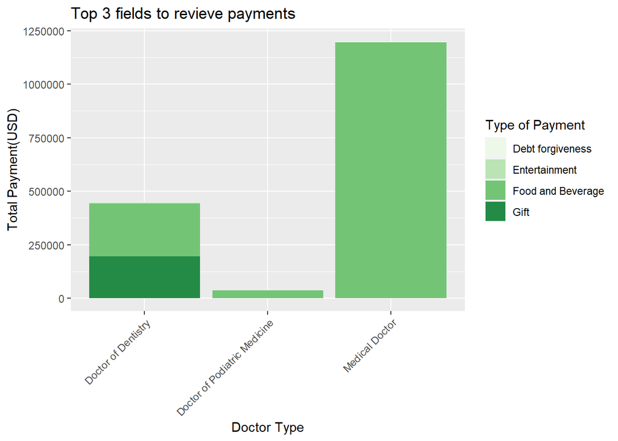

Interesting, it looks like if I just want gifts, dentistry is the way to go, but if I was hoping to be wine’d and dined, definitely stick with that M.D.

I think I’d rather have gifts, as sitting with a sales rep doesn’t sound particularly fun and since we know that Dentistry get’s the most in gifts, I’ll choose a dentist to mentor me.

Which doctor could teach me the most about accepting payments from 3rd parties?

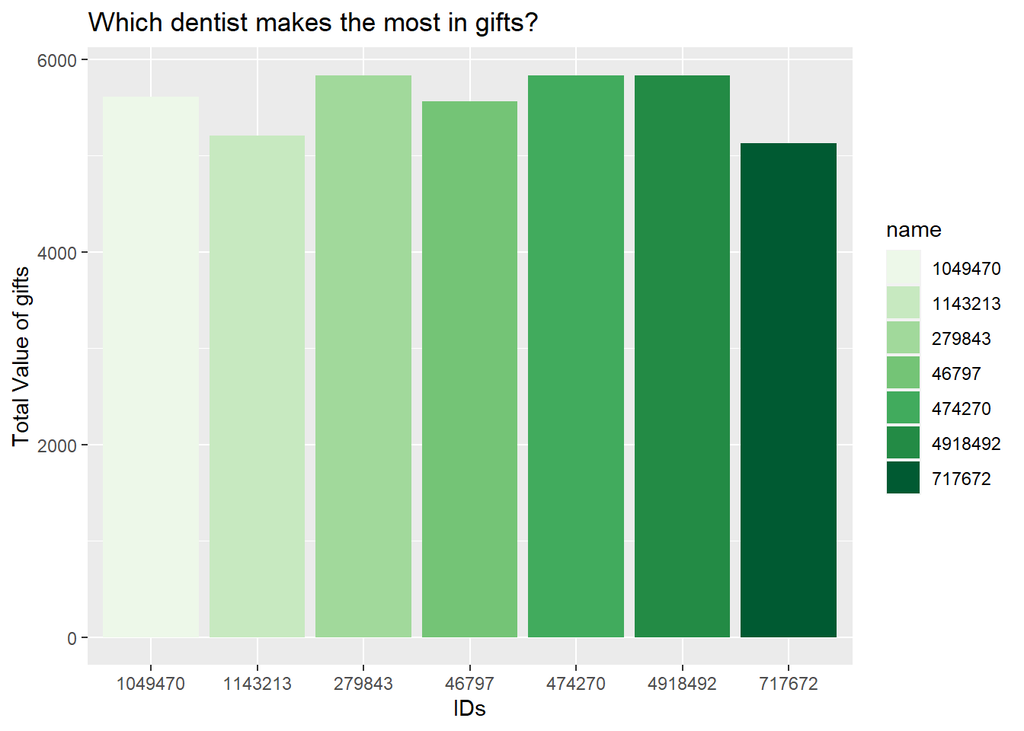

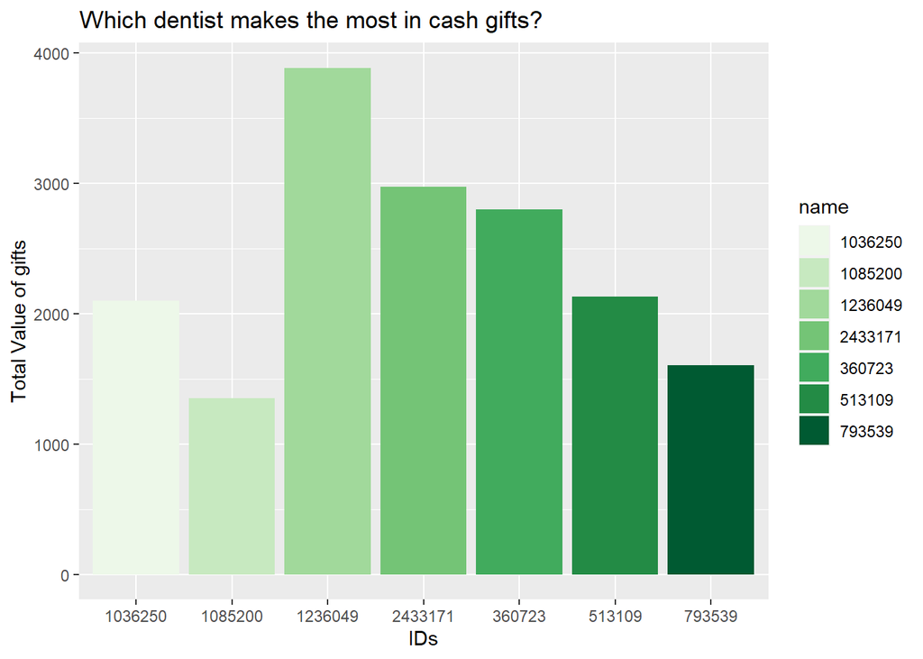

ID 1236049 or Dr. Manuel de Rosa appears to accept the most cash or cash equivalent gifts, largely from Straumann USA LLC.

If I want to cushion my salary, it looks like I should become a dentist and contact Dr. de Rosa for some advice!

All jokes aside, the level of transparency is appreciated, and while I’d rather medical professionals not received gifts from corporations, I don’t blame the doctors for receiving them, rather I would put the onus on our legislators to increase regulations on third-parties from advertising themselves in such a manner. Free samples and renting of certain medical devices and software, consulting fees, and speaking engagements are all an exchange of expertise for monetary rewards, however I am skeptical that the patient experience improves because doctors receive a gift.